# R Notebook

### Chargement du package DADA2

```r
library(dada2)
```

### Importation des données dans un objet “path”

```r
path <- "/home/rstudio/DADA2/MiSeq_SOP"
list.files(path)
```

```
##  [1] "F3D0_S188_L001_R1_001.fastq"   "F3D0_S188_L001_R2_001.fastq"
##  [3] "F3D1_S189_L001_R1_001.fastq"   "F3D1_S189_L001_R2_001.fastq"
##  [5] "F3D141_S207_L001_R1_001.fastq" "F3D141_S207_L001_R2_001.fastq"
##  [7] "F3D142_S208_L001_R1_001.fastq" "F3D142_S208_L001_R2_001.fastq"
##  [9] "F3D143_S209_L001_R1_001.fastq" "F3D143_S209_L001_R2_001.fastq"
## [11] "F3D144_S210_L001_R1_001.fastq" "F3D144_S210_L001_R2_001.fastq"
## [13] "F3D145_S211_L001_R1_001.fastq" "F3D145_S211_L001_R2_001.fastq"
## [15] "F3D146_S212_L001_R1_001.fastq" "F3D146_S212_L001_R2_001.fastq"
## [17] "F3D147_S213_L001_R1_001.fastq" "F3D147_S213_L001_R2_001.fastq"
## [19] "F3D148_S214_L001_R1_001.fastq" "F3D148_S214_L001_R2_001.fastq"
## [21] "F3D149_S215_L001_R1_001.fastq" "F3D149_S215_L001_R2_001.fastq"
## [23] "F3D150_S216_L001_R1_001.fastq" "F3D150_S216_L001_R2_001.fastq"
## [25] "F3D2_S190_L001_R1_001.fastq"   "F3D2_S190_L001_R2_001.fastq"
## [27] "F3D3_S191_L001_R1_001.fastq"   "F3D3_S191_L001_R2_001.fastq"
## [29] "F3D5_S193_L001_R1_001.fastq"   "F3D5_S193_L001_R2_001.fastq"
## [31] "F3D6_S194_L001_R1_001.fastq"   "F3D6_S194_L001_R2_001.fastq"
## [33] "F3D7_S195_L001_R1_001.fastq"   "F3D7_S195_L001_R2_001.fastq"
## [35] "F3D8_S196_L001_R1_001.fastq"   "F3D8_S196_L001_R2_001.fastq"
## [37] "F3D9_S197_L001_R1_001.fastq"   "F3D9_S197_L001_R2_001.fastq"
## [39] "filtered"                      "HMP_MOCK.v35.fasta"
## [41] "Mock_S280_L001_R1_001.fastq"   "Mock_S280_L001_R2_001.fastq"
## [43] "mouse.dpw.metadata"            "mouse.time.design"
## [45] "stability.batch"               "stability.files"
```

### Regroupement des séquences forward et reverse

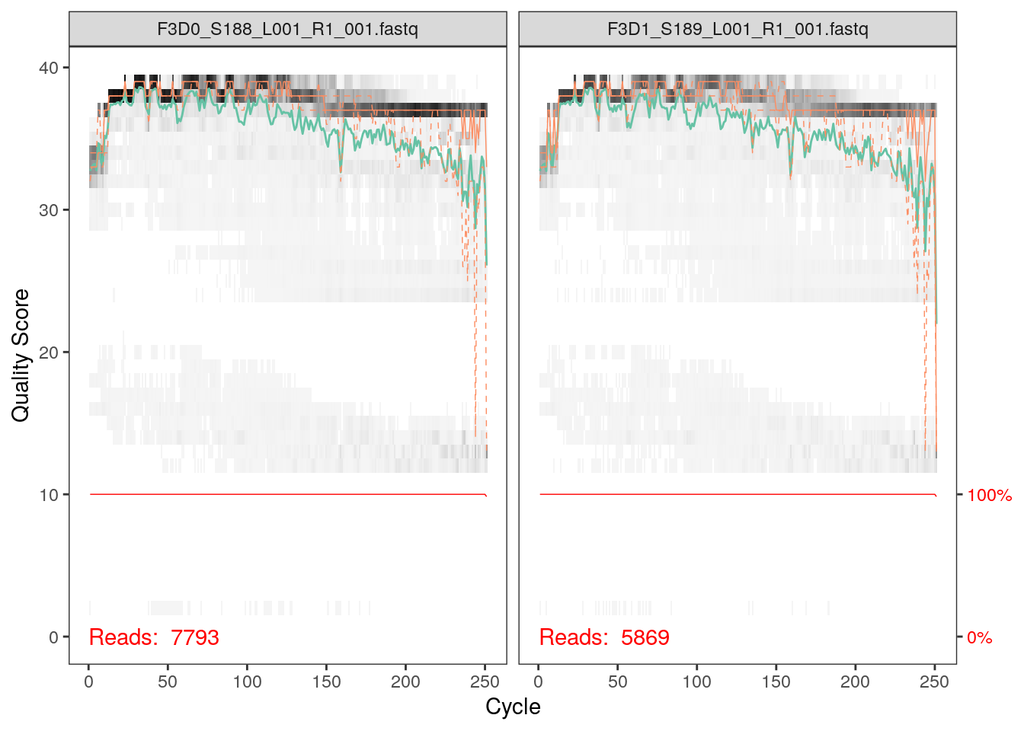

```r
fnFs <- sort(list.files(path, pattern= "_R1_001.fastq", full.names = TRUE))
fnRs <- sort(list.files(path, pattern= "_R2_001.fastq", full.names = TRUE))
sample.names <- sapply(strsplit(basename(fnFs), "_"), `[`, 1)
plotQualityProfile(fnFs[1:2])
```

##### Graphique représentant les profils de qualité des séquences forward des deux premiers échantillons.

Il est possible de voir que le score de qualité diminue pour les 10 dernières bases des séquences, pour les deux échantillons.

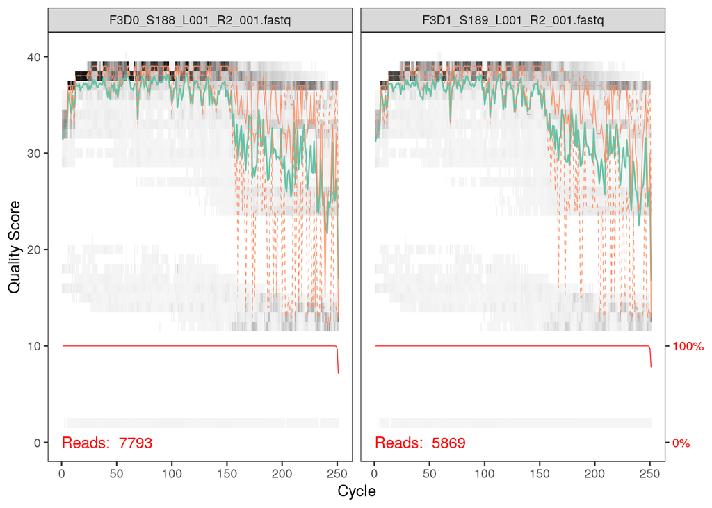

```r
plotQualityProfile(fnRs[1:2])
```

##### Graphique représentant les profils de qualité des séquences reverse des deux premiers échantillons.

Il est possible de voir que le score de qualité diminue fortement à partir d’environ la 160ème base pour les séquences des deux échantillons.

### Création d’un nouveau dossier “filtered” dans le directory et filtration des séquences

```r
filtFs <- file.path(path, "filtered", paste0(sample.names, "_F_filt.fastq.gz"))
filtRs <- file.path(path, "filtered", paste0(sample.names, "_R_filt.fastq.gz"))
names(filtFs) <- sample.names
names(filtRs) <- sample.names

out <- filterAndTrim(fnFs, filtFs, fnRs, filtRs, truncLen=c(240, 160), maxN=0, maxEE=c(2,2), truncQ=2, rm.phix=TRUE, compress = TRUE, multithread = TRUE)

head(out)
```

```
##                               reads.in reads.out
## F3D0_S188_L001_R1_001.fastq       7793      7113
## F3D1_S189_L001_R1_001.fastq       5869      5299
## F3D141_S207_L001_R1_001.fastq     5958      5463
## F3D142_S208_L001_R1_001.fastq     3183      2914
## F3D143_S209_L001_R1_001.fastq     3178      2941
## F3D144_S210_L001_R1_001.fastq     4827      4312
```

Ici, les séquences vont être filtrées selon plusieurs critères qui doivent affinés si un nombre trop impotant de séquences est enlevé du jeu de données. D’abord, la partie des séquences où le score de qualité a diminué, comme vu ci-dessus, va être supprimée. Les séquences forward vont être réduites à 240 bases, et les reverse à 160 bases. Toutes les séquences contenant un nucléotide N (maxN = 0) ou une base avec un score de qualité égal ou inférieur à 2 (truncQ = 2) seront enlevées du jeu de données. Les séquences forward et reverse pour lesquelles le nombre d’erreurs attendues calculé est supérieur à 2 seront également enlevées (maxEE = c(2,2)). Enfin, si une séquence match avec le génome de phiX, elle sera aussi supprimée (rm.phix = TRUE). L’objet “out” contient le nombre de séquences avant et après filtration pour chaque échantillon.

### Apprentissage des taux d’erreurs

```r
errF <- learnErrors(filtFs, multithread = TRUE)
```

```
## 33514080 total bases in 139642 reads from 20 samples will be used for learning the error rates.
```

```r
errR <- learnErrors(filtRs, multithread = TRUE)
```

```
## 22342720 total bases in 139642 reads from 20 samples will be used for learning the error rates.
```

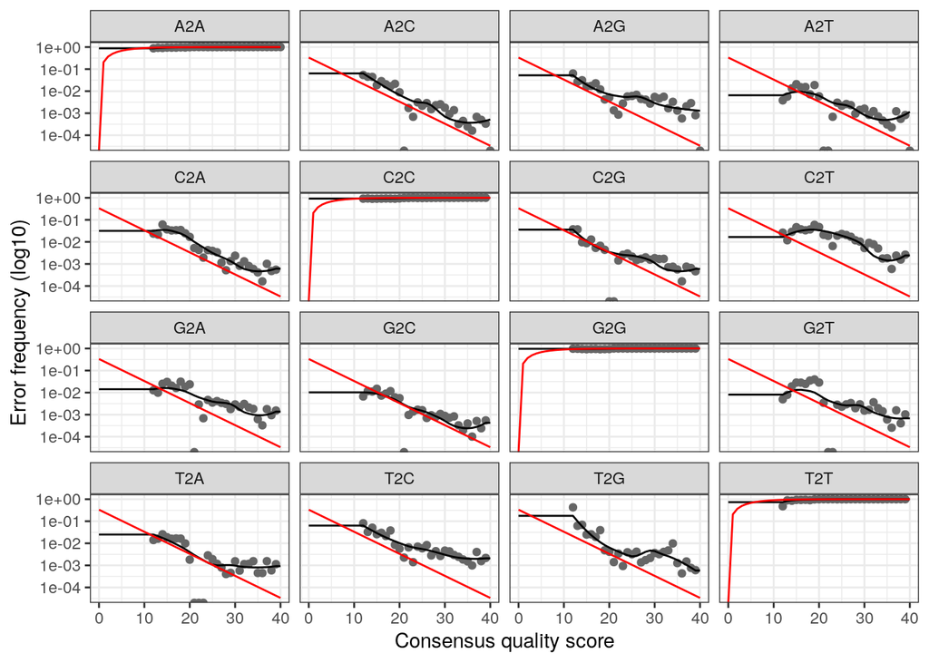

```r
plotErrors(errF, nominalQ = TRUE)
```

La fonction “learnErrors” permet de déterminer le taux d’erreur observé pour chaque transition de base possible en fonction du score de qualité dans le jeu de données. L’algorithme va alors calculer une estimation de chaque taux d’erreur (ligne noire) qui est censée suivre les taux observés. La ligne rouge correspond à la modélisation des erreurs attendues pour chaque score de qualité. Il est possible de voir que plus le score de qualité est élevé, plus le taux d’erreur est faible, sauf pour les transitions d’une base à une même base où il est maximal car plus le score de qualité est élevé plus la probabilité d’obtenir la même base est élevée. Seulement cette probabilité est ici modélisée comme une fréquence d’erreur.

### Correction des erreurs et détection des vrais variants

```r
dadaFs <- dada(filtFs, err=errF, multithread=TRUE)
```

```
## Sample 1 - 7113 reads in 1979 unique sequences.
## Sample 2 - 5299 reads in 1639 unique sequences.
## Sample 3 - 5463 reads in 1477 unique sequences.
## Sample 4 - 2914 reads in 904 unique sequences.
## Sample 5 - 2941 reads in 939 unique sequences.
## Sample 6 - 4312 reads in 1267 unique sequences.
## Sample 7 - 6741 reads in 1756 unique sequences.
## Sample 8 - 4560 reads in 1438 unique sequences.
## Sample 9 - 15637 reads in 3590 unique sequences.
## Sample 10 - 11413 reads in 2762 unique sequences.
## Sample 11 - 12017 reads in 3021 unique sequences.
## Sample 12 - 5032 reads in 1566 unique sequences.
## Sample 13 - 18075 reads in 3707 unique sequences.
## Sample 14 - 6250 reads in 1479 unique sequences.
## Sample 15 - 4052 reads in 1195 unique sequences.
## Sample 16 - 7369 reads in 1832 unique sequences.
## Sample 17 - 4765 reads in 1183 unique sequences.
## Sample 18 - 4871 reads in 1382 unique sequences.
## Sample 19 - 6504 reads in 1709 unique sequences.
## Sample 20 - 4314 reads in 897 unique sequences.
```

```r
dadaRs <- dada(filtRs, err=errR, multithread=TRUE)
```

```
## Sample 1 - 7113 reads in 1660 unique sequences.
## Sample 2 - 5299 reads in 1349 unique sequences.
## Sample 3 - 5463 reads in 1335 unique sequences.
## Sample 4 - 2914 reads in 853 unique sequences.
## Sample 5 - 2941 reads in 880 unique sequences.
## Sample 6 - 4312 reads in 1286 unique sequences.
## Sample 7 - 6741 reads in 1803 unique sequences.
## Sample 8 - 4560 reads in 1265 unique sequences.
## Sample 9 - 15637 reads in 3414 unique sequences.
## Sample 10 - 11413 reads in 2522 unique sequences.
## Sample 11 - 12017 reads in 2771 unique sequences.
## Sample 12 - 5032 reads in 1415 unique sequences.
## Sample 13 - 18075 reads in 3290 unique sequences.
## Sample 14 - 6250 reads in 1390 unique sequences.
## Sample 15 - 4052 reads in 1134 unique sequences.
## Sample 16 - 7369 reads in 1635 unique sequences.
## Sample 17 - 4765 reads in 1084 unique sequences.
## Sample 18 - 4871 reads in 1161 unique sequences.
## Sample 19 - 6504 reads in 1502 unique sequences.
## Sample 20 - 4314 reads in 732 unique sequences.
```

```r
dadaFs[[1]]
```

```
## dada-class: object describing DADA2 denoising results
## 128 sequence variants were inferred from 1979 input unique sequences.
## Key parameters: OMEGA_A = 1e-40, OMEGA_C = 1e-40, BAND_SIZE = 16
```

La fonction “dada” va alors utiliser le modèle d’erreur ci-dessus afin de corriger les erreurs de séquençage et détecter les vrais variants dans chaque échantillon. L’algorithme a détecté 1979 séquences uniques dans l’échantillon 1, dont 128 correspondent à des vrais variants.

### Alignement et fusion des séquences forward et reverse

```r
mergers <- mergePairs(dadaFs, filtFs, dadaRs, filtRs, verbose=TRUE)
head(mergers[[1]])
```

|  | sequence | abundance | forward | reverse | nmatch | nmismatch | nindel | prefer | accept |
| --- | --- | --- | --- | --- | --- | --- | --- | --- | --- |
| 1 | TACGGAGGATGCGAGCGTTATCCGGATTTATTGGGTTTAAAGGGTGCGCAGGCGGAAGAT…… | 579 | 1 | 1 | 148 | 0 | 0 | 1 | TRUE |
| 2 | TACGGAGGATGCGAGCGTTATCCGGATTTATTGGGTTTAAAGGGTGCGTAGGCGGCCTGC…… | 470 | 2 | 2 | 148 | 0 | 0 | 2 | TRUE |
| 3 | TACGGAGGATGCGAGCGTTATCCGGATTTATTGGGTTTAAAGGGTGCGTAGGCGGGCTGT…… | 449 | 3 | 4 | 148 | 0 | 0 | 1 | TRUE |
| 4 | TACGGAGGATGCGAGCGTTATCCGGATTTATTGGGTTTAAAGGGTGCGTAGGCGGGCTTT…… | 430 | 4 | 3 | 148 | 0 | 0 | 2 | TRUE |
| 5 | TACGGAGGATGCGAGCGTTATCCGGATTTATTGGGTTTAAAGGGTGCGCAGGCGGACTCT…… | 345 | 5 | 6 | 148 | 0 | 0 | 1 | TRUE |
| 6 | TACGGAGGATGCGAGCGTTATCCGGATTTATTGGGTTTAAAGGGTGCGTAGGCGGGATGC…… | 282 | 6 | 5 | 148 | 0 | 0 | 2 | TRUE |

La fonction “mergePairs” permet d’aligner le complément-inverse des séquences reverse avec les séquences forward, avant de les fusionner pour obtenir la séquence d’intérêt entière. La séquence fusionner sera conservée dans le jeu de données uniquement si la zone de chevauchement entre les séquences forward et reverse est identique, et si cette zone est de minimum 12 bases (ces paramètres peuvent être modifiés). Ici le data.frame montre que dans le premier échantillon il y a 127 séquences différentes, c’est-à-dire un variant de moins qu’à l’étape d’avant. L’abondance de chacune d’elle dans l’échantillon est également indiquée.

### Construction d’une table d’observation

```r
seqtab <- makeSequenceTable(mergers)
dim(seqtab)
```

```
## [1]  20 293
```

La fonction “makeSequenceTable” permet de créer une table d’observation des différents variants. La fonction “dim” permet de voir le nombres de lignes et de colonnes de cette table, respectivement 20 et 293 ici. Il y a donc 293 variants différents qui ont été identifiés en tout dans le jeu de données.

```r
table(nchar(getSequences(seqtab)))
```

```
##
## 251 252 253 254 255
##   1  88 196   6   2
```

Ce code permet de voir la longueur de la séquence pour chaque variant. Il est possible de voir qu’elles tombent toutes dans la gamme de longueur pour la region V4 de l’ARN 16S.

### Elimination des chimères

```r
seqtab.nochim <- removeBimeraDenovo(seqtab, method = "consensus", multithread=TRUE, verbose=TRUE)
dim(seqtab.nochim)
```

```
## [1]  20 232
```

```r
sum(seqtab.nochim)/sum(seqtab)
```

```
## [1] 0.9640374
```

Ce chiffre correspond à la fraction de toutes les séquences fusionnées qui n’étaient pas des chimères, c’est-à-dire 96%. A ne pas confondre avec le pourcentage de variants du jeu de données qui étaient des chimères.

### Tableau récapitulatif du nombre de séquences enlevées à chaque étape

```r
getN <- function(x) sum(getUniques(x))
track <- cbind(out, sapply(dadaFs, getN), sapply(dadaRs, getN), sapply(mergers, getN), rowSums(seqtab.nochim))
colnames(track) <- c("input", "filtered", "denoisedF", "denoisedR", "merged", "nonchim")
rownames(track) <- sample.names
head(track)
```

```
##        input filtered denoisedF denoisedR merged nonchim
## F3D0    7793     7113      6976      6979   6540    6528
## F3D1    5869     5299      5227      5239   5028    5017
## F3D141  5958     5463      5331      5357   4986    4863
## F3D142  3183     2914      2799      2830   2595    2521
## F3D143  3178     2941      2822      2868   2553    2519
## F3D144  4827     4312      4151      4228   3646    3507
```

Ce tableau résume le nombre de séquences enlevées à chaque étape du pipeline pour l’ensemble des échantillons. La majorité des séquences ont été gardées.

### Taxonomie

```r
taxa <- assignTaxonomy(seqtab.nochim, "silva_nr99_v138.1_train_set.fa.gz", multithread=TRUE)
taxa.print <- taxa
row.names(taxa.print) <- NULL
head(taxa.print)
```

```
##      Kingdom    Phylum         Class         Order           Family
## [1,] "Bacteria" "Bacteroidota" "Bacteroidia" "Bacteroidales" "Muribaculaceae"
## [2,] "Bacteria" "Bacteroidota" "Bacteroidia" "Bacteroidales" "Muribaculaceae"
## [3,] "Bacteria" "Bacteroidota" "Bacteroidia" "Bacteroidales" "Muribaculaceae"
## [4,] "Bacteria" "Bacteroidota" "Bacteroidia" "Bacteroidales" "Muribaculaceae"
## [5,] "Bacteria" "Bacteroidota" "Bacteroidia" "Bacteroidales" "Bacteroidaceae"
## [6,] "Bacteria" "Bacteroidota" "Bacteroidia" "Bacteroidales" "Muribaculaceae"
##      Genus
## [1,] NA
## [2,] NA
## [3,] NA
## [4,] NA
## [5,] "Bacteroides"
## [6,] NA
```

Ici, la fonction assignTaxonomy permet, à partir d’une base de données taxonomiques, d’attribuer une taxonomie à chaque séquence du jeu de données. Ici on peut voir que pour la plupart des séquences, la taxonomie attribuée s’arrête à la famille.

### Précision de l’analyse

```r
unqs.mock <- seqtab.nochim["Mock",]
unqs.mock <- sort(unqs.mock[unqs.mock>0], decreasing=TRUE)
cat("DADA2 inferred", length(unqs.mock), "sample sequences present in the Mock community.\n")
```

```
## DADA2 inferred 20 sample sequences present in the Mock community.
```

```r
mock.ref <- getSequences(file.path(path, "HMP_MOCK.v35.fasta"))
match.ref <- sum(sapply(names(unqs.mock), function(x) any(grepl(x, mock.ref))))
cat("Of those,", sum(match.ref), "were exact matches to the expected reference sequences.\n")
```

```
## Of those, 20 were exact matches to the expected reference sequences.
```

La communauté mock est une communauté de référence dont toutes les séquences sont connues, à laquelle les échantillons vont être comparés afin d’évaluer la qualité du séquençage et de la pipeline d’analyse. Ici, il est possible de voir que les 20 séquences de la communauté mock analysées avec la pipeline DADA2 match avec les séquences de références attendues. Cela indique que l’analyse et le séquençage sont qualitatifs.

### Partie bonus phyloseq

```r
library(phyloseq)
library(ggplot2)
library(Biostrings)
```

```r
samples.out <- rownames(seqtab.nochim)
subject <- sapply(strsplit(samples.out, "D"), `[`, 1)
gender <- substr(subject,1,1)
subject <- substr(subject,2,999)
day <- as.integer(sapply(strsplit(samples.out, "D"), `[`, 2))
samdf <- data.frame(Subject=subject, Gender=gender, Day=day)
samdf$When <- "Early"
samdf$When[samdf$Day>100] <- "Late"
rownames(samdf) <- samples.out
```

```r
ps <- phyloseq(otu_table(seqtab.nochim, taxa_are_rows=FALSE),
               sample_data(samdf),
               tax_table(taxa))
ps <- prune_samples(sample_names(ps) != "Mock", ps)
```

```r
dna <- Biostrings::DNAStringSet(taxa_names(ps))
names(dna) <- taxa_names(ps)
ps <- merge_phyloseq(ps, dna)
taxa_names(ps) <- paste0("ASV", seq(ntaxa(ps)))
ps
```

```
## phyloseq-class experiment-level object
## otu_table()   OTU Table:         [ 232 taxa and 19 samples ]
## sample_data() Sample Data:       [ 19 samples by 4 sample variables ]
## tax_table()   Taxonomy Table:    [ 232 taxa by 6 taxonomic ranks ]
## refseq()      DNAStringSet:      [ 232 reference sequences ]
```

Phyloseq permet de créer plusieurs objets à partir des données produites avec DADA2, notamment une table d’OTU, une table de taxonomie, un objet contenant l’ensemble des séquences et un tableau de métadonnées.

#### Visualisation de la diversité alpha

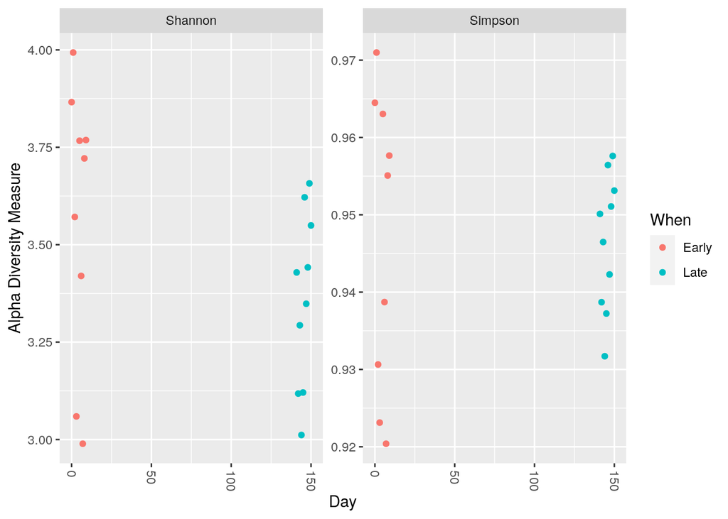

```r
plot_richness(ps, x="Day", measures=c("Shannon", "Simpson"), color="When")
```

Ce graphique montre la diversité alpha, ou biodiversité, des échantillons en fonction du nombre de jour après le sevrage des souris. Il est possible de voir qu’il n’y a aucune différence de biodiversité flagrante entre les échantillons Early et Late.

```r
ps.prop <- transform_sample_counts(ps, function(otu) otu/sum(otu))
ord.nmds.bray <- ordinate(ps.prop, method="NMDS", distance="bray")
```

```
## *** Best solution repeated 1 times
```

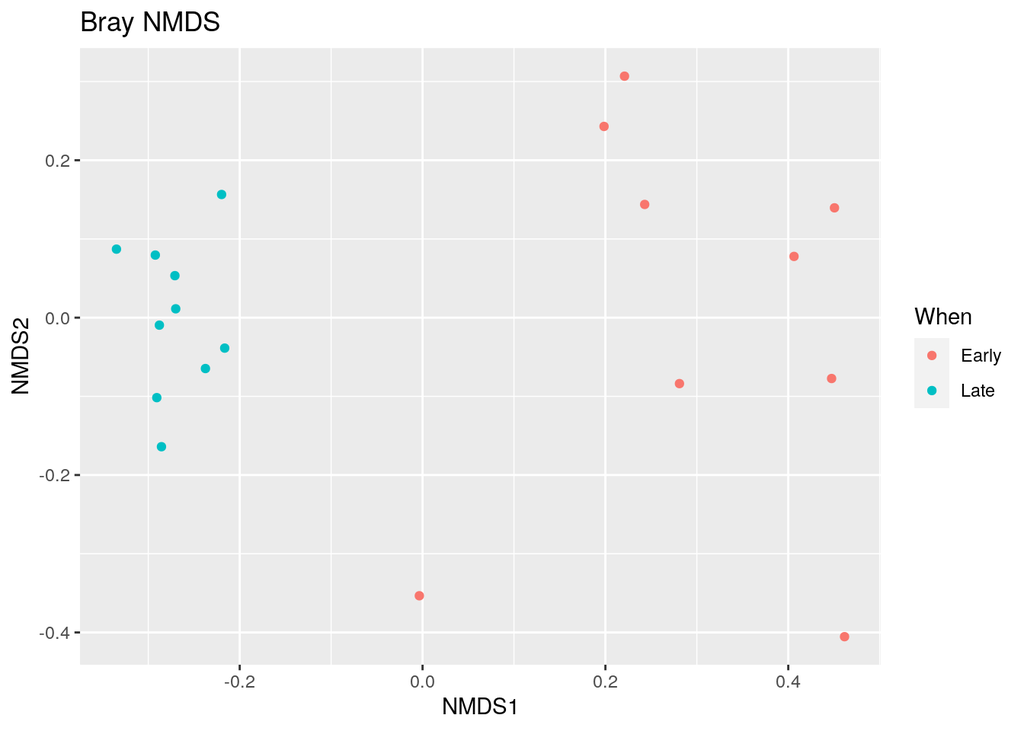

```r
plot_ordination(ps.prop, ord.nmds.bray, color="When", title="Bray NMDS")
```

L’ordination réalisée ici permet par contre d’observer une différence entre les échantillons Late et Early. En effet, avec l’ordination, plus deux points sont distants plus ils sont dissimilaires. Il est également possible de voir que les échantillons Early sont moins homogènes en terme de diversité que les échantillons Late.

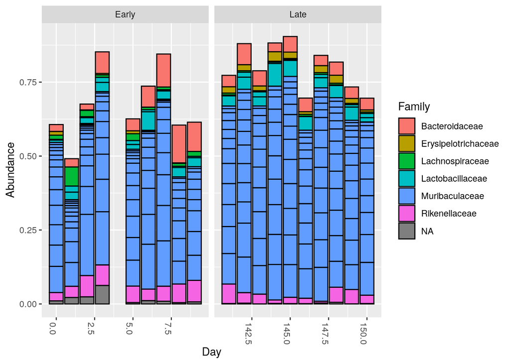

```r
top20 <- names(sort(taxa_sums(ps), decreasing=TRUE))[1:20]
ps.top20 <- transform_sample_counts(ps, function(OTU) OTU/sum(OTU))
ps.top20 <- prune_taxa(top20, ps.top20)
plot_bar(ps.top20, x="Day", fill="Family") + facet_wrap(~When, scales="free_x")
```

Ce barplot prend en compte les 20 séquences les plus représentées. Il permet de voir qu’il y a une différence en terme d’abondance entre les échantillons Early et Late mais que la diversité n’est pas extrêmement différente.